# The End of JSON Validation Hell

## A Practical Guide to OpenAI's Structured Outputs

### *Data Tech Conference 2025*

Code and Slides at https://github.com/ericness/end-of-json-validation-hell

## Agenda

- Presenter Bio
- Problem Statement
- Demo: Extracting Structured Data using Prompts
- Analyzing Problems
- Demo: Using OpenAI Structured Output
- Conclusion

## Eric Ness

### Principal Machine Learning Engineer @ C.H. Robinson

C.H. Robinson is a Fortune 250 supply chain broker headquarterd in Eden Prairie

Two LLM-Based Projects in Production

- Converting email orders to JSON requests for orders API
- Categorizing freight using national standard codes

LinkedIn: https://www.linkedin.com/in/ericnessdata/

## Extracting Data from Unstructured Input

- Many use cases need to extract structured data from unstructured input
- Often occurs when data is coming from external sources before entering organization's tech landscape
  - Outside sources could be documents, images, emails, and so forth
  - Need to be translated into the structured data that internal systems require
- Previously handled by users or complex ML systems
- In the last 3 years LLMs have enabled a wide-spread solution
- Typically the output format is JSON

## Prompt-Only Approach

- Uses prompts to describe the task and the desired output schema
- Doesn't guarantee correct schema due to probabilistic nature of LLM output
- Even 99% accuracy on schema isn't sufficient for many production applications
- Invalid instances need to be handled manually or through an exception process

## Demo: Extracting Structured Data using Prompts

- Use a HuggingFace dataset to demonstrate using a prompt-only approach to extracting data
- `SetFit/bbc-news` contains 2225 BBC news articles from 2004-2005
- Each article is labeled under one of five categories

```python
dataset = load_dataset("SetFit/bbc-news")

train_df = pd.DataFrame(dataset["train"])
test_df = pd.DataFrame(dataset["test"])
combined_df = pd.concat([train_df, test_df])

print("Dataset Overview:")
print(f"Dataset size: {len(combined_df)}")
print("\nLabel distribution in training set:")
print(combined_df["label_text"].value_counts())

train_df["text_length"] = train_df["text"].str.len()
print(f"\nText length mean: {train_df['text_length'].mean():.2f}")
```

```
Dataset Overview:
Dataset size: 2225

Label distribution in training set:
label_text
sport            511
business         510
politics         417
tech             401
entertainment    386
Name: count, dtype: int64

Text length mean: 2288.95
```

```python
sample_text = combined_df["text"].iloc[0]
display(
    HTML(
        f'<div style="white-space: pre-wrap; font-family: monospace;">{sample_text}</div>'
    )
)
```

wales want rugby league training wales could follow england s lead by training with a rugby league club. england have already had a three-day session with leeds rhinos and wales are thought to be interested in a similar clinic with rivals st helens. saints coach ian millward has given his approval but if it does happen it is unlikely to be this season. saints have a week s training in portugal next week while wales will play england in the opening six nations match on 5 february. we have had an approach from wales confirmed a saints spokesman. it s in the very early stages but it is something we are giving serious consideration to. st helens who are proud of their welsh connections are obvious partners for the welsh rugby union despite a spat in 2001 over the collapse of kieron cunningham s proposed £500 000 move to union side swansea. a similar cross-code deal that took iestyn harris from leeds to cardiff in 2001 did go through before the talented stand-off returned to the 13-man code with bradford bulls. kel coslett who famously moved from wales to league in the 1960s is currently saints football manager while clive griffiths - wales defensive coach - is a former st helens player and is thought to be the man behind the latest initiative. scott gibbs the former wales and lions centre played for st helens from 1994-96 and was in the challenge cup-winning team at wembley in 1996.

### Schema for Extraction Part 1

```python
class ArticleCategory(StrEnum):
    BUSINESS = "business"
    ENTERTAINMENT = "entertainment"
    POLITICS = "politics"
    SPORT = "sport"
    TECH = "tech"


class NamedEntityType(StrEnum):
    COMPANY = "company"
    COUNTRY = "country"
    LOCATION = "location"
    PERSON = "person"
    TEAM = "team"
```

### Schema for Extraction Part 2

`pydantic` `BaseModel`s to define the output schema

```python
class NamedEntity(BaseModel):
    name: str = Field(description="Name of the person, company, etc.")
    type: NamedEntityType = Field(description="Type of named entity")


class NewsArticle(BaseModel):
    title: str = Field(
        description="Appropriate headline for the news article"
    )
    category: ArticleCategory = Field(
        description="Category of news that the article belongs to"
    )
    mentioned_entities: list[NamedEntity] = Field(
        description="List of all named entities in the article",
        default_factory=list,
    )
    summary: str = Field(
        description="Brief summary of the article content."
    )
    length: int = Field(description="Length of the article in words.")
```

````python
EXTRACTION_PROMPT = """
Read the news article below and extract the information into a
JSON object. This is the schema you should use to extract the
data. It's provided in standard JSON Schema format.

```json
{news_article_schema}
```

Here is the news article to generate the JSON data for. The article
is surrounded by triple backticks.

```
{news_article}
```

Format your response as a JSON object surrounded by triple backticks
with the 'json' identifier like this:
```json
your JSON object here
```

Be sure to follow the provided schema exactly.
"""
````

### JSON Schema

Standard format for specifying the structure of JSON data.

```python
news_article_schema = NewsArticle.model_json_schema()
print(json.dumps(news_article_schema, indent=2))
```

```
{
  "$defs": {
    "ArticleCategory": {
      "enum": [
        "business",
        "entertainment",
        "politics",
        "sport",
        "tech"
      ],
      "title": "ArticleCategory",
      "type": "string"
    },
    "NamedEntity": {
      "properties": {
        "name": {
          "description": "Name of the person, company, etc.",
          "title": "Name",
          "type": "string"
        },
        "type": {
          "$ref": "#/$defs/NamedEntityType",
          "description": "Type of named entity"
        }
      },
      "required": [
        "name",
        "type"
      ],
      "title": "NamedEntity",
      "type": "object"
    },
    "NamedEntityType": {
      "enum": [
        "company",
        "country",
        "location",
        "person",
        "team"
      ],
```

[output cut: 27 more lines]

```
    "length": {
      "description": "Length of the article in words.",
      "title": "Length",
      "type": "integer"
    }
  },
  "required": [
    "title",
    "category",
    "summary",
    "length"
  ],
  "title": "NewsArticle",
  "type": "object"
}
```

### Run the Extraction for 100 Articles for Each Model

```python
openai_client = AsyncOpenAI()

ARTICLE_COUNT = 100
MAX_CONCURRENT_TASKS = 3
loop_semaphore = asyncio.Semaphore(MAX_CONCURRENT_TASKS)

success_count = 0
model_names = ["gpt-3.5-turbo", "gpt-4-turbo", "gpt-4o-mini"]

results = defaultdict(list)
for model_name in model_names:
    tasks = [
        extract_article_data(
            article, model_name, openai_client, loop_semaphore
        )
        for article in combined_df["text"][:ARTICLE_COUNT]
    ]

    for f in tqdm(asyncio.as_completed(tasks), total=len(tasks)):
        results[model_name].append(await f)

    success_count = sum(1 for result in results[model_name] if result)
    print(
        f"For {model_name} successfully validated {success_count} of {ARTICLE_COUNT} records"
    )
```

[output not shown]

### Validation Results

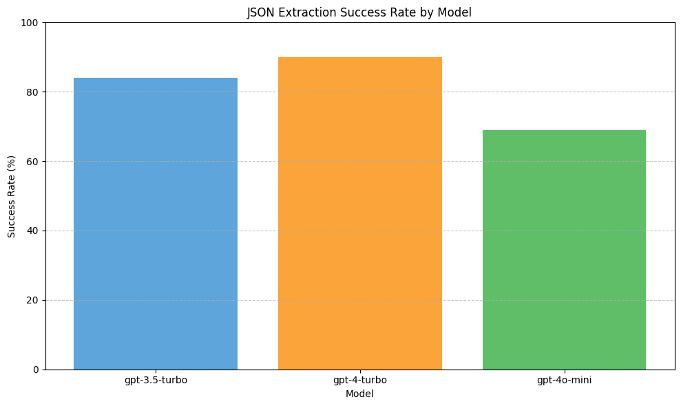

```python
plt.show()
```

### Using logprobs to Analyze the Results

The `logprobs` parameter returns the log probabilities of the top tokens for each token in the output

```python
def generate_and_visualize_json(article_idx=0):
    """Generate JSON for an article and visualize the output with heatmap"""
    client = OpenAI()
    article = combined_df["text"].iloc[article_idx]

    formatted_prompt = EXTRACTION_PROMPT.format(
        news_article_schema=json.dumps(news_article_schema, indent=2),
        news_article=article,
    )

    # Call the API with logprobs
    response = client.beta.chat.completions.parse(
        model="gpt-4o-mini",  # Or any other model you want to test
        messages=[{"role": "user", "content": formatted_prompt}],
        temperature=0.0,
        logprobs=True,
        top_logprobs=5,
    )

    visualize_json_with_heatmap(response)

    return response
```

```python
response = generate_and_visualize_json(15)
```

[output not shown]

**Token Probability Legend:**

## Demo: Using OpenAI Structured Output

- Modern OpenAI models can force a specified JSON output schema
- Only tokens that are a valid part of the schema are allowed
- Released in August 2024
- Supported by GPT-4o and GPT-4.1 as well as reasoning models like o3 and o4-mini
- Specifying the schema can be done by either a JSON Schema or Pydantic model in Python

### New Extraction Prompt

The new prompt only needs the news article as input since the schema is specified in the model call.

````python
STRUCTURED_EXTRACTION_PROMPT = """
Read the news article below and extract the information into a
JSON object.

Here is the news article to generate the JSON data for. The article
is surrounded by triple backticks.

```
{news_article}
```

"""
````

### Extract Data Using Structured Output

Notice the `response_format` parameter which specifies the output format using the `pydantic` class `NewsArticle`.

```python
async def extract_article_data(
    article: str,
    model_name: str,
    client: AsyncOpenAI,
    semaphore: asyncio.Semaphore,
) -> bool:
    """Returns true if JSON is appropriately formatted"""

    formatted_prompt = STRUCTURED_EXTRACTION_PROMPT.format(
        news_article=article
    )

    async with semaphore:
        response = await client.beta.chat.completions.parse(
            model=model_name,
            messages=[{"role": "user", "content": formatted_prompt}],
            temperature=0.0,
            response_format=NewsArticle,
        )

        news_article = response.choices[0].message.parsed
        return isinstance(news_article, NewsArticle)
```

### Run the Extraction for 100 Articles

Use "gpt-4o-mini" which is the most cost-effective model that supports structured output.

```python
openai_client = AsyncOpenAI()

ARTICLE_COUNT = 100
MAX_CONCURRENT_TASKS = 4
loop_semaphore = asyncio.Semaphore(MAX_CONCURRENT_TASKS)

success_count = 0
model_names = ["gpt-4o-mini"]

results = defaultdict(list)
for model_name in model_names:
    tasks = [
        extract_article_data(
            article, model_name, openai_client, loop_semaphore
        )
        for article in combined_df["text"][:ARTICLE_COUNT]
    ]

    for f in tqdm(asyncio.as_completed(tasks), total=len(tasks)):
        results[model_name].append(await f)

    success_count = sum(1 for result in results[model_name] if result)
    print(
        f"For {model_name} successfully validated {success_count} of {ARTICLE_COUNT} records"
    )
```

```
For gpt-4o-mini successfully validated 100 of 100 records
```

## Validation Results

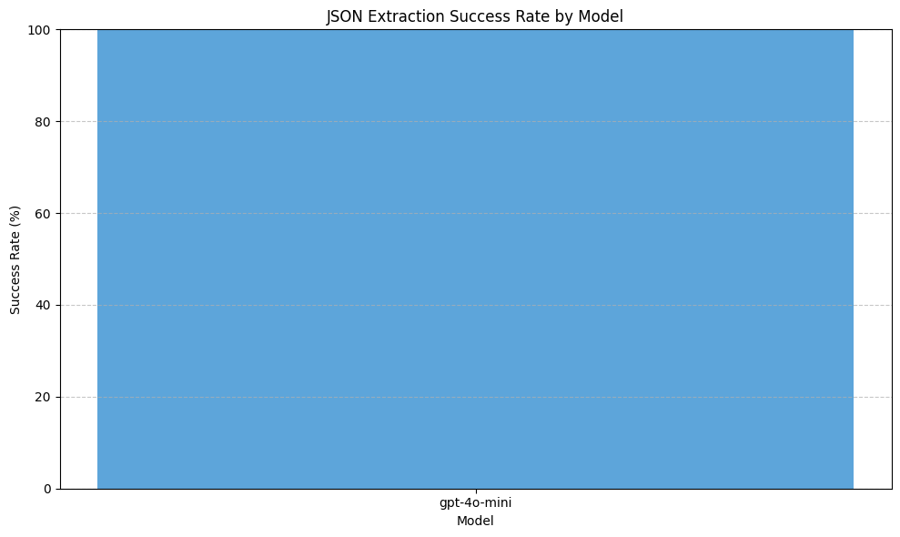

```python
plt.show()
```

```python
response = generate_structured_and_visualize_json(11)
```

[output not shown]

**Token Probability Legend:**

## Conclusion

- Use structured output for any data extraction task
- Guarantees the data format is correct
- Prevents data validation problems in downstream applications

## Questions?

https://github.com/ericness/end-of-json-validation-hell